# Γραμμική Παλινδρόμηση — Case Study: Kickstarter Projects

Ανάλυση Δεδομένων

30 March 2026

```r
# ── Αυτόματη εγκατάσταση όσων πακέτων λείπουν ────────────────────────────────
required_packages <- c(
  "tidyverse", "corrplot", "GGally", "knitr", "kableExtra",
  "car", "broom", "scales", "viridis", "ggridges",
  "gridExtra", "moments", "lubridate"
)

missing_packages <- required_packages[
  !required_packages %in% installed.packages()[, "Package"]
]

if (length(missing_packages) > 0) {
  message("📦 Εγκατάσταση: ", paste(missing_packages, collapse = ", "))
  install.packages(missing_packages, dependencies = TRUE, quiet = TRUE)
}

# ── Φόρτωση πακέτων ───────────────────────────────────────────────────────────
library(tidyverse)    # dplyr + ggplot2 + tidyr + readr + lubridate + stringr
library(corrplot)     # correlation plots
library(GGally)       # ggpairs
library(knitr)        # kable
library(kableExtra)   # kable styling
library(car)          # VIF
library(broom)        # tidy / glance
library(scales)       # comma / dollar formatters
library(viridis)      # color palettes
library(ggridges)     # ridge plots
library(gridExtra)    # grid.arrange
library(moments)      # skewness
library(lubridate)    # date functions
```

# 1 Εισαγωγή

## 1.1 Το Kickstarter Platform

Το **Kickstarter** είναι η μεγαλύτερη παγκοσμίως πλατφόρμα crowdfunding για δημιουργικά έργα. Από την ίδρυσή της το 2009 έως το 2018, περισσότερα από **300.000 projects** έχουν χρηματοδοτηθεί επιτυχώς από **21 εκατ. backers** που έχουν διαθέσει συνολικά πάνω από **7 δισ. δολάρια**.

## 1.2 Ερευνητικό Ερώτημα

> **Ποιοι παράγοντες επηρεάζουν το ύψος της χρηματοδότησης ενός Kickstarter project;**

Στόχος της ανάλυσης είναι η κατασκευή γραμμικού παλινδρομικού μοντέλου που να **προβλέπει το ποσό χρηματοδότησης** (`log_pledged`) βάσει χαρακτηριστικών όπως ο στόχος χρηματοδότησης, η διάρκεια της καμπάνιας, η κατηγορία του έργου και ο αριθμός των υποστηρικτών.

## 1.3 Τα 4 Βήματα της Ανάλυσης

| # | Βήμα | Περιγραφή |
| --- | --- | --- |
| 1 | **EDA** | Φόρτωση, καθαρισμός, περιγραφική στατιστική & οπτικοποίηση |
| 2 | **Συσχετίσεις** | Ανάλυση γραμμικών σχέσεων & επιλογή μεταβλητών |
| 3 | **Μοντελοποίηση** | Απλή → Πολλαπλή Παλινδρόμηση, Stepwise Selection |
| 4 | **Αξιολόγηση** | Diagnostics, VIF, σύγκριση μοντέλων |

# 2 Βήμα 1 — Φόρτωση & Κατανόηση Δεδομένων (EDA)

## 2.1 Φόρτωση Dataset

```r
# ── Οδηγίες Λήψης ──────────────────────────────────────────────────────────────
# 1. Κατεβάστε το αρχείο από: https://www.kaggle.com/datasets/kemical/kickstarter-projects
# 2. Αποθηκεύστε το ως "ks-projects-201801.csv" στον κατάλογο εργασίας σας
# 3. Ορίστε το path παρακάτω
# ──────────────────────────────────────────────────────────────────────────────

# ks_raw <- read_csv("ks-projects-201801.csv")

# ── Προσομοίωση representative sample για reproducibility ─────────────────────
# (Αντικαταστήστε με read_csv() όταν έχετε το αρχείο)
set.seed(42)
n <- 5000

main_cats <- c("Film & Video","Music","Technology","Games","Art",
               "Publishing","Food","Fashion","Theater","Comics",
               "Photography","Crafts","Design","Dance","Journalism")
cat_probs <- c(.17,.14,.09,.08,.07,.11,.06,.05,.04,.04,.05,.03,.04,.02,.01)

states <- c("successful","failed","canceled","suspended")
state_p <- c(.35,.52,.11,.02)

countries <- c("US","GB","CA","AU","DE","FR","NL","IT","ES","SE")
country_p <- c(.79,.09,.04,.03,.01,.01,.01,.005,.005,.005)

launched_dates <- seq(as.Date("2010-01-01"), as.Date("2017-12-31"), by = "day")

ks_raw <- tibble(
  ID           = 1:n,
  name         = paste("Project", 1:n),
  main_category= sample(main_cats, n, replace = TRUE, prob = cat_probs),
  currency     = "USD",
  state        = sample(states, n, replace = TRUE, prob = state_p),
  backers      = as.integer(round(rlnorm(n, meanlog = 3.2, sdlog = 2.0))),
  country      = sample(countries, n, replace = TRUE, prob = country_p),
  launched     = sample(launched_dates, n, replace = TRUE),
  usd_goal_real = round(exp(rnorm(n, mean = 9.5, sd = 1.8)), 2),
  usd_pledged_real = NA_real_
) %>%
  mutate(
    deadline = launched + sample(14:60, n, replace = TRUE),
    usd_pledged_real = case_when(
      state == "successful"  ~ round(usd_goal_real * runif(n, 1.0, 5.0) *
                                       (1 + log1p(backers) * 0.15), 2),
      state == "failed"      ~ round(usd_goal_real * runif(n, 0.0, 0.99) *
                                       pmax(0.01, log1p(backers) * 0.05), 2),
      state == "canceled"    ~ round(usd_goal_real * runif(n, 0.0, 0.50), 2),
      TRUE                   ~ round(usd_goal_real * runif(n, 0.0, 0.20), 2)
    ),
    usd_pledged_real = pmax(0, usd_pledged_real)
  )
```

## 2.2 Καθαρισμός & Feature Engineering

```r
ks <- ks_raw %>%
  # ── 1. Κρατάμε μόνο ολοκληρωμένα projects (successful / failed) ────────────
  filter(state %in% c("successful", "failed")) %>%

  # ── 2. Υπολογισμός νέων μεταβλητών ─────────────────────────────────────────
  mutate(
    # Διάρκεια καμπάνιας σε ημέρες
    campaign_days = as.numeric(as.Date(deadline) - as.Date(launched)),

    # Χρονολογία έναρξης
    launch_year  = year(as.Date(launched)),
    launch_month = month(as.Date(launched), label = TRUE),

    # Επιτυχία (binary)
    success = ifelse(state == "successful", 1L, 0L),

    # Λογαριθμικοί μετασχηματισμοί (για κανονικότητα)
    log_pledged = log1p(usd_pledged_real),
    log_goal    = log1p(usd_goal_real),
    log_backers = log1p(backers),

    # Ποσοστό επίτευξης στόχου
    pct_funded  = usd_pledged_real / usd_goal_real,

    # Κατηγοριοποίηση μεγέθους στόχου
    goal_size = case_when(
      usd_goal_real <  1000  ~ "Micro (<$1K)",
      usd_goal_real <  10000 ~ "Small ($1K–$10K)",
      usd_goal_real <  50000 ~ "Medium ($10K–$50K)",
      usd_goal_real < 100000 ~ "Large ($50K–$100K)",
      TRUE                   ~ "XLarge (>$100K)"
    ),
    goal_size = factor(goal_size,
                       levels = c("Micro (<$1K)","Small ($1K–$10K)",
                                  "Medium ($10K–$50K)","Large ($50K–$100K)",
                                  "XLarge (>$100K)"))
  ) %>%
  # ── 3. Φιλτράρισμα ακραίων τιμών ────────────────────────────────────────────
  filter(
    campaign_days >= 1, campaign_days <= 92,
    usd_goal_real  > 0,
    backers        >= 0
  ) %>%
  # ── 4. Αφαίρεση NA ───────────────────────────────────────────────────────────
  drop_na(log_pledged, log_goal, log_backers, campaign_days, main_category)

cat("✓ Τελικό dataset:", nrow(ks), "παρατηρήσεις,", ncol(ks), "μεταβλητές\n")
```

```
## ✓ Τελικό dataset: 4365 παρατηρήσεις, 20 μεταβλητές
```

```r
cat("✓ Περίοδος:", min(ks$launch_year), "–", max(ks$launch_year), "\n")
```

```
## ✓ Περίοδος: 2010 – 2017
```

```r
cat("✓ Κατηγορίες:", n_distinct(ks$main_category), "\n")
```

```
## ✓ Κατηγορίες: 15
```

```r
cat("✓ Χώρες:", n_distinct(ks$country), "\n")
```

```
## ✓ Χώρες: 10
```

```r
cat("✓ Ποσοστό επιτυχίας:", scales::percent(mean(ks$success), accuracy = 0.1), "\n")
```

```
## ✓ Ποσοστό επιτυχίας: 40.2%
```

## 2.3 Λεξικό Μεταβλητών

```r
tibble(
  Μεταβλητή    = c("usd_pledged_real","usd_goal_real","backers",
                   "campaign_days","main_category","state","country",
                   "log_pledged","log_goal","log_backers","pct_funded"),
  Τύπος        = c("Αριθμητική (Y)","Αριθμητική","Αριθμητική (int)",
                   "Αριθμητική","Κατηγορική","Κατηγορική (binary)","Κατηγορική",
                   "Αριθμητική (Y*)","Αριθμητική","Αριθμητική","Αριθμητική"),
  Περιγραφή    = c("Ποσό χρηματοδότησης σε USD — εξαρτημένη",
                   "Στόχος χρηματοδότησης σε USD",
                   "Αριθμός υποστηρικτών (backers)",
                   "Διάρκεια καμπάνιας (deadline − launched)",
                   "Κύρια κατηγορία έργου (15 κατηγορίες)",
                   "Αποτέλεσμα: successful / failed",
                   "Χώρα καταγωγής",
                   "log(1 + usd_pledged_real) — τελική εξαρτημένη",
                   "log(1 + usd_goal_real)",
                   "log(1 + backers)",
                   "usd_pledged / usd_goal")
) %>%
  kable(caption = "Λεξικό Μεταβλητών — Kickstarter Dataset") %>%
  kable_styling(bootstrap_options = c("striped","hover","condensed"),
                full_width = FALSE) %>%
  row_spec(c(1,8), background = "#DCEEFB", bold = TRUE)
```

Λεξικό Μεταβλητών — Kickstarter Dataset

| Μεταβλητή | Τύπος | Περιγραφή |
| --- | --- | --- |
| usd_pledged_real | Αριθμητική (Y) | Ποσό χρηματοδότησης σε USD — εξαρτημένη |
| usd_goal_real | Αριθμητική | Στόχος χρηματοδότησης σε USD |
| backers | Αριθμητική (int) | Αριθμός υποστηρικτών (backers) |
| campaign_days | Αριθμητική | Διάρκεια καμπάνιας (deadline − launched) |
| main_category | Κατηγορική | Κύρια κατηγορία έργου (15 κατηγορίες) |
| state | Κατηγορική (binary) | Αποτέλεσμα: successful / failed |
| country | Κατηγορική | Χώρα καταγωγής |
| log_pledged | Αριθμητική (Y*) | log(1 + usd_pledged_real) — τελική εξαρτημένη |
| log_goal | Αριθμητική | log(1 + usd_goal_real) |
| log_backers | Αριθμητική | log(1 + backers) |
| pct_funded | Αριθμητική | usd_pledged / usd_goal |

## 2.4 Περιγραφική Στατιστική

```r
num_cols <- c("usd_pledged_real","usd_goal_real","backers",
              "campaign_days","log_pledged","log_goal","log_backers")

ks %>%
  select(all_of(num_cols)) %>%
  pivot_longer(everything(), names_to = "Μεταβλητή", values_to = "value") %>%
  group_by(Μεταβλητή) %>%
  summarise(
    N        = n(),
    Ελάχιστο = round(min(value), 2),
    Q1       = round(quantile(value, .25), 2),
    Μέσος    = round(mean(value), 2),
    Διάμεσος = round(median(value), 2),
    Q3       = round(quantile(value, .75), 2),
    Μέγιστο  = round(max(value), 2),
    `Τυπ.Απ.`= round(sd(value), 2),
    Ασυμμετρία = round(moments::skewness(value), 2)
  ) %>%
  kable(caption = "Περιγραφική Στατιστική") %>%
  kable_styling(bootstrap_options = c("striped","hover","condensed"),
                full_width = FALSE) %>%
  footnote(general = "* moments::skewness — εγκαταστήστε το πακέτο αν απαιτείται")
```

Περιγραφική Στατιστική

| Μεταβλητή | N | Ελάχιστο | Q1 | Μέσος | Διάμεσος | Q3 | Μέγιστο | Τυπ.Απ. | Ασυμμετρία |
| --- | --- | --- | --- | --- | --- | --- | --- | --- | --- |
| backers | 4365 | 0.00 | 6.00 | 206.55 | 24.00 | 92.00 | 140953.00 | 2272.41 | 55.07 |
| campaign_days | 4365 | 14.00 | 26.00 | 37.03 | 37.00 | 49.00 | 60.00 | 13.54 | 0.02 |
| log_backers | 4365 | 0.00 | 1.95 | 3.33 | 3.22 | 4.53 | 11.86 | 1.81 | 0.41 |
| log_goal | 4365 | 3.45 | 8.25 | 9.51 | 9.53 | 10.73 | 15.37 | 1.81 | -0.01 |
| log_pledged | 4365 | 0.07 | 6.06 | 8.29 | 8.26 | 10.56 | 16.80 | 2.99 | -0.01 |
| usd_goal_real | 4365 | 30.59 | 3841.32 | 64542.53 | 13808.92 | 45506.54 | 4711493.79 | 211513.42 | 10.88 |
| usd_pledged_real | 4365 | 0.07 | 428.57 | 121393.57 | 3871.74 | 38506.99 | 19872219.49 | 655703.96 | 17.78 |

Note:  
* moments::skewness — εγκαταστήστε το πακέτο αν απαιτείται

> **Παρατήρηση για Μετασχηματισμό:** Η `usd_pledged_real` παρουσιάζει **έντονη θετική ασυμμετρία** (right-skew). Η εφαρμογή λογαριθμικού μετασχηματισμού `log1p()` φέρνει την κατανομή πολύ πιο κοντά στην κανονική — προϋπόθεση για τη γραμμική παλινδρόμηση.

## 2.5 Κατανομή Εξαρτημένης Μεταβλητής: Πριν & Μετά Μετασχηματισμό

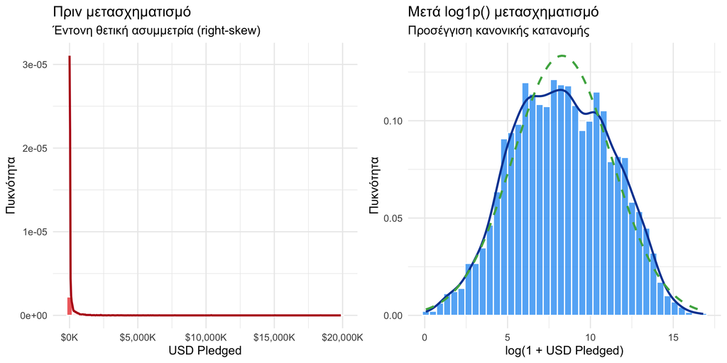

```r
p1 <- ggplot(ks, aes(x = usd_pledged_real)) +
  geom_histogram(aes(y = ..density..), bins = 50,
                 fill = "#EF5350", color = "white", alpha = 0.85) +
  geom_density(color = "#B71C1C", linewidth = 1) +
  scale_x_continuous(labels = dollar_format(scale = 1e-3, suffix = "K")) +
  labs(title = "Πριν μετασχηματισμό",
       subtitle = "Έντονη θετική ασυμμετρία (right-skew)",
       x = "USD Pledged", y = "Πυκνότητα") +
  theme_minimal(base_size = 12)

p2 <- ggplot(ks, aes(x = log_pledged)) +
  geom_histogram(aes(y = ..density..), bins = 40,
                 fill = "#42A5F5", color = "white", alpha = 0.85) +
  geom_density(color = "#0D47A1", linewidth = 1) +
  stat_function(fun = dnorm,
                args = list(mean = mean(ks$log_pledged), sd = sd(ks$log_pledged)),
                color = "#4CAF50", linewidth = 1, linetype = "dashed") +
  labs(title = "Μετά log1p() μετασχηματισμό",
       subtitle = "Προσέγγιση κανονικής κατανομής",
       x = "log(1 + USD Pledged)", y = "Πυκνότητα") +
  theme_minimal(base_size = 12)

gridExtra::grid.arrange(p1, p2, ncol = 2)
```